# `Chapter#4 NumPy Basics: Arrays and Vectorized Computation`

# Methods for boolean arrays:

- any(), all()
- These methods also work with non-boolean arrays, where non-zero elements evaluate to True.

# Unique and other Set Logic:

- Contrast `np.unique` with the pure Python alternative: `sorted(set(arrName))`
- `np.in1d`, tests membership of the values in one array in another, returning a `boolean array`:

```python
values = np.array([6, 0, 0, 3, 2, 5, 6])
np.in1d(values, [2, 3, 6])
```

```
array([ True, False, False,  True,  True, False,  True])
```

# File Input and Output with Arrays

- NumPy is able to save and load data to and from disk either in text or binary format. We only discuss NumPy’s built-in binary format.
- Arrays are saved `by default` in an `uncompressed raw binary format` with file extension `.npy`.
- You save multiple arrays in an `uncompressed archive` using `np.savez` and passing the `arrays as keyword arguments`
- When loading an `.npz file`, you get back a `dict-like object` that loads the individual arrays lazily

# Linear Algebra

### 1) `np.diag(arr, k)`

- **The diag() function is used to extract a diagonal or construct a diagonal array.**
- Return the diagonal (or off-diagonal) elements of a square matrix as a 1D array,
- or convert a 1D array into a square matrix with zeros on the off-diagonal
- `K` is diagonal and is `optional parameter`. `The default is 0`. Use `k>0 for diagonals above the main diagonal`, and `k<0 for diagonals below the main diagonal`

## Example 1:

### Pictorial Representation

[figure not shown]

```python
a = np.arange(12).reshape((4,3))
a
```

```
array([[ 0,  1,  2],
       [ 3,  4,  5],
       [ 6,  7,  8],
       [ 9, 10, 11]])
```

```python
np.diag(a)
```

```
array([0, 4, 8])
```

## Example 2:

```python
a = np.arange(12).reshape((4,3))
np.diag(a, k=1)
```

```
array([1, 5])
```

## Example 3

```python
a = np.arange(12).reshape((4,3))
np.diag(a, k=-1)
```

```
array([ 3,  7, 11])
```

## Example 4

#### convert a 1D array into a square matrix with zeros on the off-diagonal

```python
a = np.arange(12).reshape((4,3))
a
```

```
array([[ 0,  1,  2],
       [ 3,  4,  5],
       [ 6,  7,  8],
       [ 9, 10, 11]])
```

```python
b = np.diag(a)
b
```

```
array([0, 4, 8])
```

```python
np.diag(b)
```

```
array([[0, 0, 0],
       [0, 4, 0],
       [0, 0, 8]])
```

```python
np.diag(np.diag(a))
```

```
array([[0, 0, 0],
       [0, 4, 0],
       [0, 0, 8]])
```

### np.trace()

- Compute the sum of the diagonal elements

```python
arr = np.eye(4, dtype="int32")
arr
```

```
array([[1, 0, 0, 0],
       [0, 1, 0, 0],
       [0, 0, 1, 0],
       [0, 0, 0, 1]])
```

```python
# arr.trace()

np.trace(arr)
```

```
4
```

# Pseudorandom Number Generation

- you can get a 4 × 4 array of samples from the standard normal distribution using normal:

  ```
  samples = np.random.normal(size=(4, 4))
  ```

```python
samples = np.random.normal(size=(4, 4))
samples
```

```
array([[-0.198571  ,  0.54952326, -1.60395172,  0.50184499],
       [-0.8050926 , -0.70441228, -0.55273046, -0.48594149],
       [-1.54220781, -0.91798573,  0.4067151 , -0.82948599],
       [ 1.76680114, -0.48113257, -0.34890996,  1.15075424]])
```

```python
from random import normalvariate
```

```python
N = 1000000
```

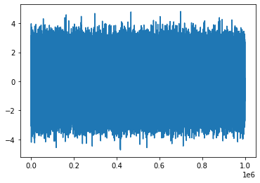

```python
# normalvariate(mean, StandarDeviation)

import matplotlib.pyplot as plt

nums = []
for i in range(N):
    samples = normalvariate(0, 1)
    nums.append(samples)

# Plotting a graph
plt.plot(nums)
plt.show()
```

We say that `these are pseudorandom numbers` because they are `generated by an algorithm with deterministic behavior based on the seed of the random number generator`. You can `change NumPy’s random number generation seed using np.random.seed:`

```python
np.random.seed(1234)
```

The data generation functions in numpy.random `use a global random seed`. `To avoid global state`, you can `use numpy.random.RandomState` to `create a random number generator isolated from others:`

```python
randomNumberGenerator = np.random.RandomState(1234)
randomNumberGenerator
```

```
RandomState(MT19937) at 0x77F2778
```

```python
randomNumberGenerator.randn(10)
```

```
array([ 0.47143516, -1.19097569,  1.43270697, -0.3126519 , -0.72058873,
        0.88716294,  0.85958841, -0.6365235 ,  0.01569637, -2.24268495])
```